# Lecture 18 - Multivariate Community Analysis

Bill Perry

# Introduction: Why NMDS?

### The Problem with Ecological Community Data

- Ecological community data presents unique challenges for traditional statistical methods
- When sampling species abundances across sites
- encounter data that is sparse (most species are absent from most sites) - many zeros
- exhibits non-linear relationships between species and environmental gradients
- has no clear distributional form
- Principal Components Analysis (PCA) works beautifully for continuous environmental variables
  - assumes linear relationships
  - can leverage correlations between variables
  - for species abundance data - assumptions often fail *spectacularly*
- **NMDS offers a fundamentally different approach**:
  - instead of trying to preserve exact distances or maximize variance explained
  - focuses on **preserving the *rank order* of similarities between samples**
  - makes it remarkably robust for ecological data.

# **Lecture 18:** NMDS - Multivariate Community Analysis

**Data - built in R and other plac**es

| **Code** | **Description of the variable** |
| --- | --- |
| das | Distance from the source [km] |
| alt | Altitude [m a.s.l.] |
| pen | Slope [per thousand] |
| deb | Mean minimum discharge [m<sup>3</sup>s<sup>-1</sup>] |
| pH | pH of water |
| dur | Calcium concentration (hardness) [mgL<sup>-1</sup>] |
| pho | Phosphate concentration [mgL<sup>-1</sup>] |
| nit | Nitrate concentration [mgL<sup>-1</sup>] |
| amn | Ammonium concentration [mgL<sup>-1</sup>] |
| oxy | Dissolved oxygen [mgL<sup>-1</sup>] |
| dbo | Biological oxygen demand [mgL<sup>-1</sup>] |

| Code | Common Name (English) | Family |
| --- | --- | --- |
| Chb | Bullhead | Cottidae |
| Tru | Brown trout | Salmonidae |
| Vai | Minnow | Cyprinidae |
| Loc | Stone loach | Balitoridae |
| Omb | Grayling | Salmonidae |
| Bla | Souffia | Cyprinidae |
| Hot | Common nase | Cyprinidae |
| Tox | Sofie | Cyprinidae |
| Van | Dace | Cyprinidae |
| Che | Chub | Cyprinidae |
| Bar | Barbel | Cyprinidae |
| Lot | Burbot | Lotidae |
| Spi | Spirlin | Cyprinidae |
| Gou | Gudgeon | Cyprinidae |
| Bro | Pike | Esocidae |
| Per | Perch | Percidae |
| Tan | Tench | Cyprinidae |
| Gar | Roach | Cyprinidae |
| Lam | Brook lamprey | petromizonidae |

# Today’s Data: The Doubs River

### About the Doubs River Dataset

- **Study System:**
  - Doubs River, France
  - 29 sites from upstream to downstream
  - Collected by Verneaux (1973)
  - Classic community ecology dataset
- **Two Datasets:**
  1. **Environmental**: 11 water quality variables
  2. **Species**: 27 fish species abundances (0-5 scale)
- **Research Questions:**
  - How do fish communities change along the river?
  - Which environmental factors drive community composition?
  - Are there distinct community types?

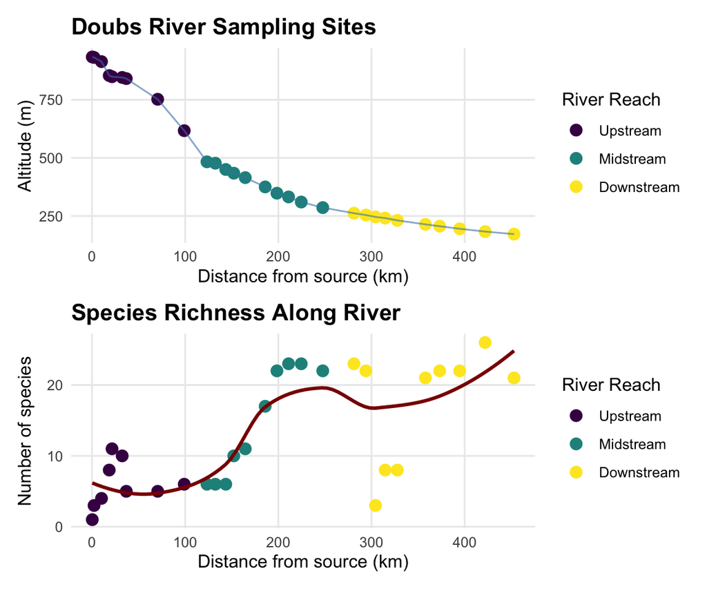

# Non-metric Multidimensional Scaling (NMDS)

- **What is NMDS?**
  - **Overview of NMDS:**
    - **Purpose**: Visualize dissimilarity between objects in 2D/3D space
    - **Goal**: Preserve rank order of distances, not exact distances
    - **Method**: Iterative re-positioning to minimize stress
    - **Output**: Ordination plot showing relationships between samples
  - **Key Differences from PCA:**
    - Uses dissimilarity matrices (not covariance)
    - Non-parametric (rank-based)
    - Better for non-linear ecological relationships
    - No assumption about data distribution
- Before running NMDS - analyzing **dissimilarity matrices** not raw abundance data
  - dissimilarity matrix contains values for every pair of samples = “how different”
  - typically range from 0 (identical) to 1 (completely different).

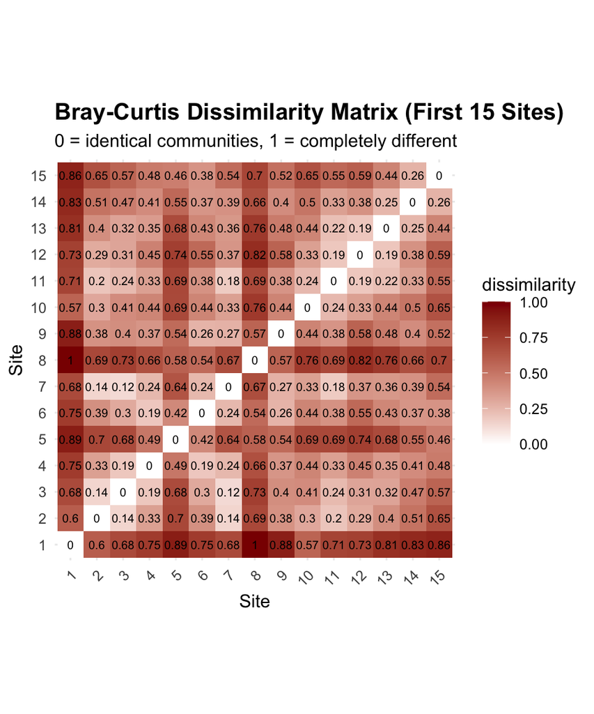

# Why Bray-Curtis for Community Data?

- **Bray-Curtis dissimilarity** is standard choice for community data because it handles zeros appropriately (**joint absences don’t contribute to similarity**)
  - bounded between 0 and 1
  - weights by abundance (not just presence/absence) - ignores joint absences entirely
  - Similarity is based only on what’s actually present and shared between sites
  - performs well with sparse data

The formula is:

$$BC_{jk} = \frac{\sum_i |y_{ij} - y_{ik}|}{\sum_i (y_{ij} + y_{ik})}$$

Where $y_{ij}$ is the abundance of species $i$ at site $j$

- **numerator sums up the absolute differences in abundance for each species between two sites**
- **denominator sums up the total abundance at both sites**
- Bray-Curtis asks: **“Of all the individuals at these two sites, what proportion would need to be moved to make the sites identical?”**

# The NMDS Algorithm

- **What NMDS Actually Does**
  - NMDS tries to place samples in a low-dimensional space (usually 2D)
  - so **rank order** of distances in ordination matches **rank order** of dissimilarities in original matrix
- Not your PCA which preserves *exact* distances (or variance)
- NMDS only cares about relative ordering:
  - if site A is more similar to site B than to site C in the original data
  - then A should be closer to B than to C in the ordination

# How NMDS Works step by step

- **The NMDS Algorithm:**
  1. **Calculate dissimilarity matrix** between all pairs of sites
  2. **Start with random configuration** of points in 2D space
  3. **Calculate stress** = **difference between original distances and ordination distances**
  4. **Move points** to reduce stress
  5. **Repeat** until stress cannot be reduced further
  6. **Try multiple random starts** to avoid local minima
- **Stress Values:**
  - < 0.1: Good representation
  - 0.1-0.2: Acceptable
  - > 0.2: Poor representation

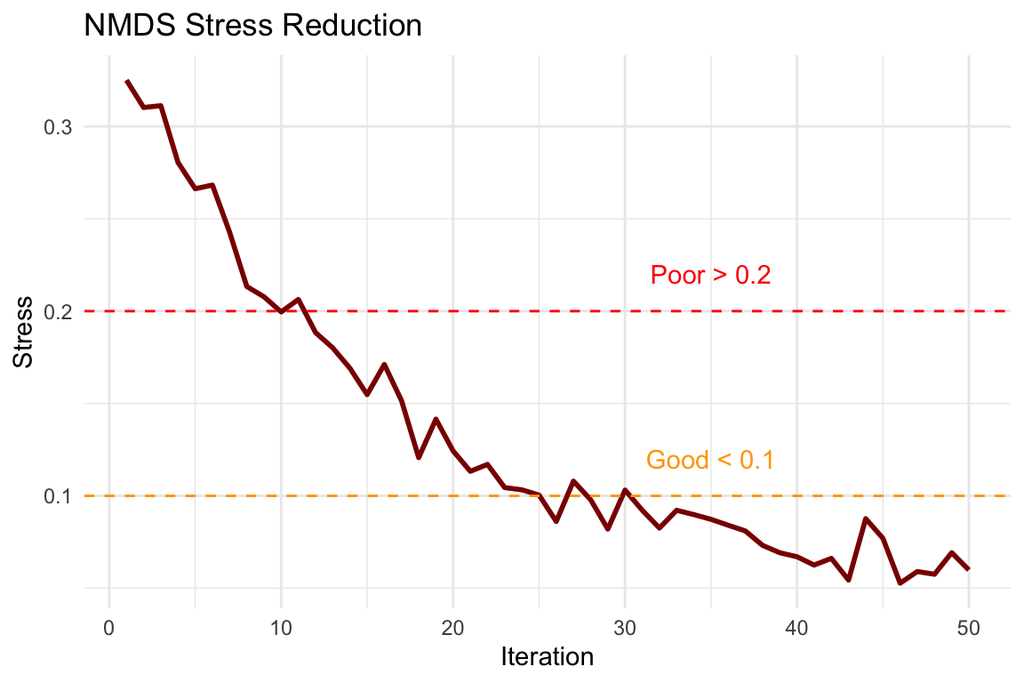

# Understanding Stress

- **What is Stress?**
  - **Stress** is key diagnostic for NMDS quality
  - measures disagreement between original dissimilarities and distances in ordination
  - stress is calculated by first ranking all pairwise dissimilarities
  - then calculating corresponding distances in the ordination
  - fitting a monotonic regression line to the relationship between these
  - finally computing sum of squared deviations from this line.
- Lower stress means ordination better represents original relationships
- **The Shepard Diagram: Visualizing Stress**
  - **Shepard diagram** (or stress plot) is primary diagnostic tool for NMDS
  - shows relationship between original dissimilarities (x-axis) and ordination distances (y-axis) with a fitted monotonic line
  - If NMDS is working well - points should closely follow the line
  - Scatter indicates loss of information.

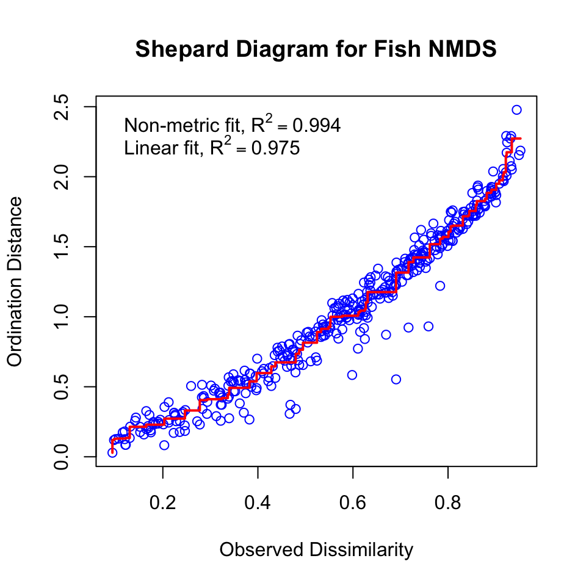

# Interpreting the Shepard Diagram

- Shepard diagram
  - each point represents one pair of sites
  - x-axis shows their original Bray-Curtis dissimilarity
  - y-axis shows their distance in the 2D ordination
  - stepped line is a monotonic regression, = can only go up/stay flat not down
  - because NMDS preserves rank order - “stress” = scatter around line
- **Insights from our Shepard diagram:**
  - minimal scatter
- **Stress Guidelines**
  - Clarke (1993) widely-used guidelines for interpreting stress
    - <0.05 excellent representation w/no misinterpretation
    - 0.05 - 0.10 good ordination - no real risk of false inferences
    - 0.10 - 0.20 usable ordination but details at lower end interpreted cautiously
    - 0.20 and 0.30 used with caution/potentially higher dimensions considered
    - >0.30 = random placement.

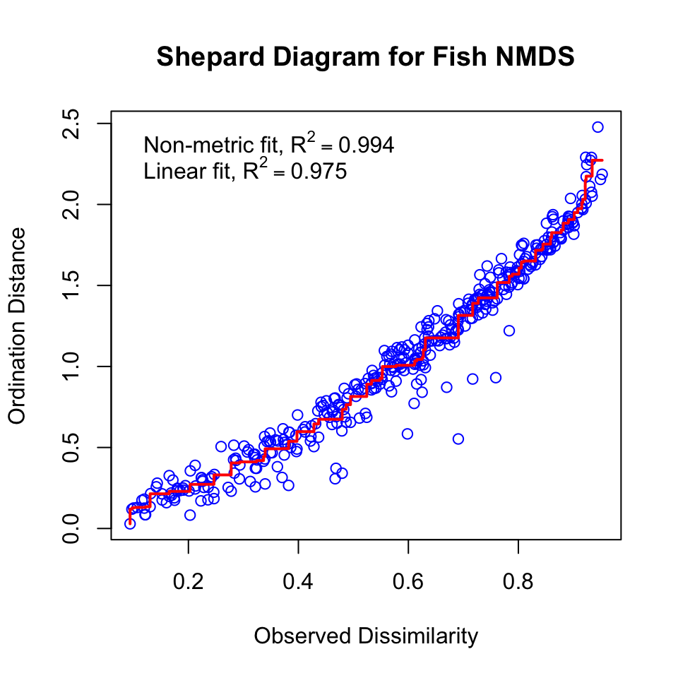

# Choosing the Number of Dimensions

- How do we know 2 dimensions is enough?
- create a **scree plot** showing stress for different numbers of dimensions:

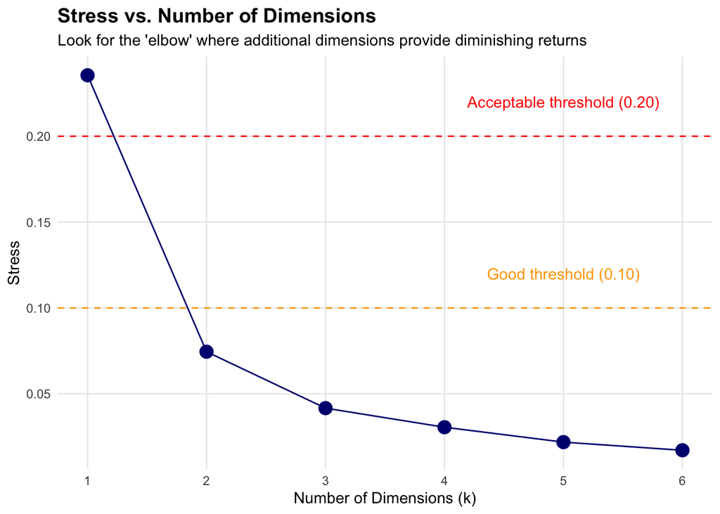

# NMDS Assumptions

- **NMDS Assumptions:**
- ✅ **Few assumptions:**
  - Samples are independent
  - Dissimilarity measure is appropriate
  - Sufficient data for stable solution
- ❌ **No assumptions about:**
  - Data distribution
  - Linear relationships
  - Homoscedasticity
  - Normality
- **This makes NMDS very robust for ecological data!**

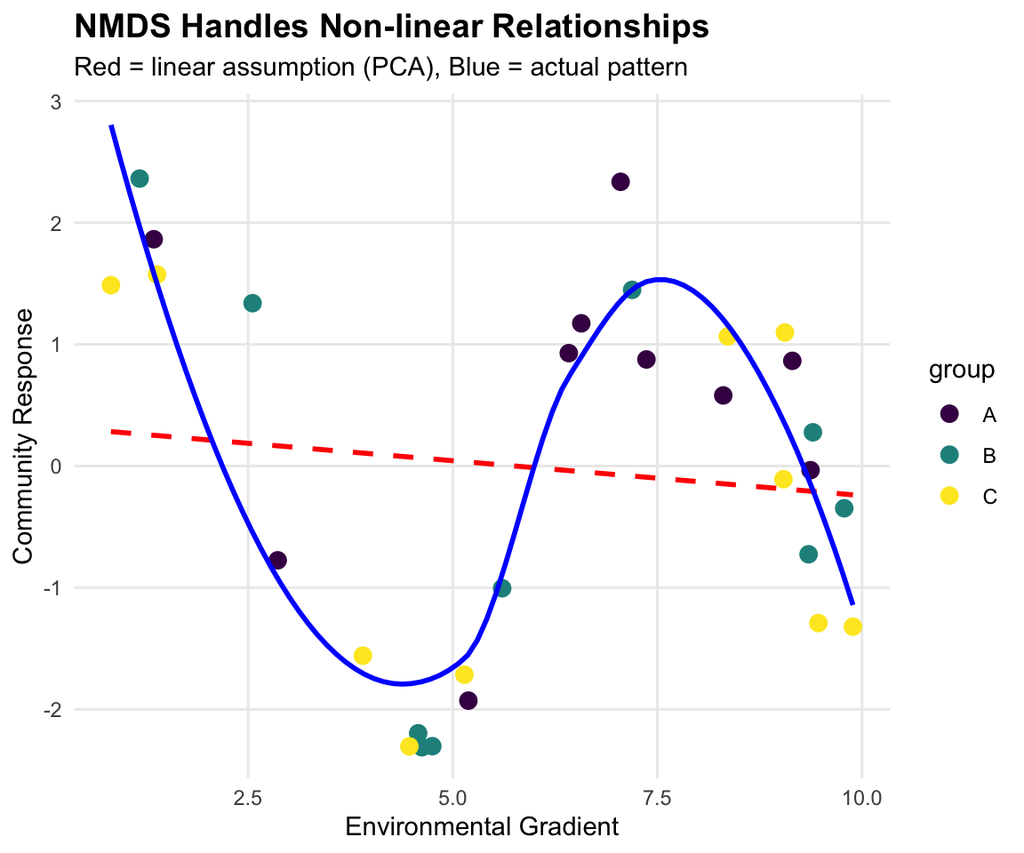

# NMDS in Practice

### Running NMDS on Fish Communities

```r
# Prepare species data (remove site column)
spe_matrix <- doubs_spe %>% select(-site, -reach) %>% as.matrix()
# Add small constant to avoid issues with zeros
spe_matrix <- spe_matrix + 0.1
# Run NMDS with multiple random starts
set.seed(123)
fish_nmds <- metaMDS(spe_matrix, distance = "bray",  # Bray-Curtis dissimilarity
                     k = 2,   trymax = 100)            # 2 dimensions + Maximum tries
## Run 0 stress 0.07449349
## Run 1 stress 0.1201175
## Run 2 stress 0.1201749
## Run 3 stress 0.1195174
## Run 4 stress 0.1201175
## Run 5 stress 0.1468615
## Run 6 stress 0.1395204
## Run 7 stress 0.09450578
## Run 8 stress 0.07460885
## ... Procrustes: rmse 0.02069815  max resid 0.09861179
## Run 9 stress 0.1273318
## Run 10 stress 0.1200159
## Run 11 stress 0.1273318
## Run 12 stress 0.07449349
## ... Procrustes: rmse 4.373442e-06  max resid 1.595028e-05
## ... Similar to previous best
## Run 13 stress 0.09450578
## Run 14 stress 0.140665
## Run 15 stress 0.07459993
## ... Procrustes: rmse 0.02014078  max resid 0.09796964
## Run 16 stress 0.1262615
## Run 17 stress 0.07460885
## ... Procrustes: rmse 0.02069823  max resid 0.09861196
## Run 18 stress 0.09134568
## Run 19 stress 0.07460885
## ... Procrustes: rmse 0.02069807  max resid 0.09861147
## Run 20 stress 0.07460885
## ... Procrustes: rmse 0.02069863  max resid 0.09861444
## *** Best solution repeated 1 times
```

```r
cat("Final stress:", round(fish_nmds$stress, 3))
## Final stress: 0.074
```

# NMDS in Practice

- **Code Explanation:**
- `fish_nmds <- metaMDS(spe_matrix, distance = "bray", # Bray-Curtis dissimilarity`
  - `k = 2, trymax = 100) # 2 dimensions + Maximum tries`
- `metaMDS()`: Main NMDS function from vegan package
  - `distance = "bray"`: Bray-Curtis dissimilarity (best for abundances)
  - `k = 2`: Two dimensions for plotting
  - `trymax = 100`: Try 100 random starting configurations
  - Small constant added to avoid zero-distance issues

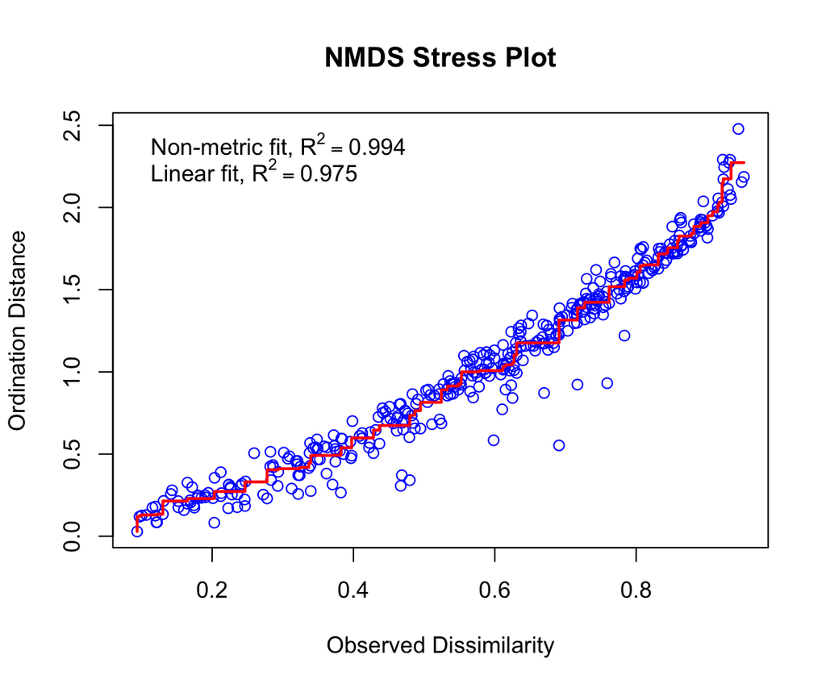

# Interpreting NMDS Output

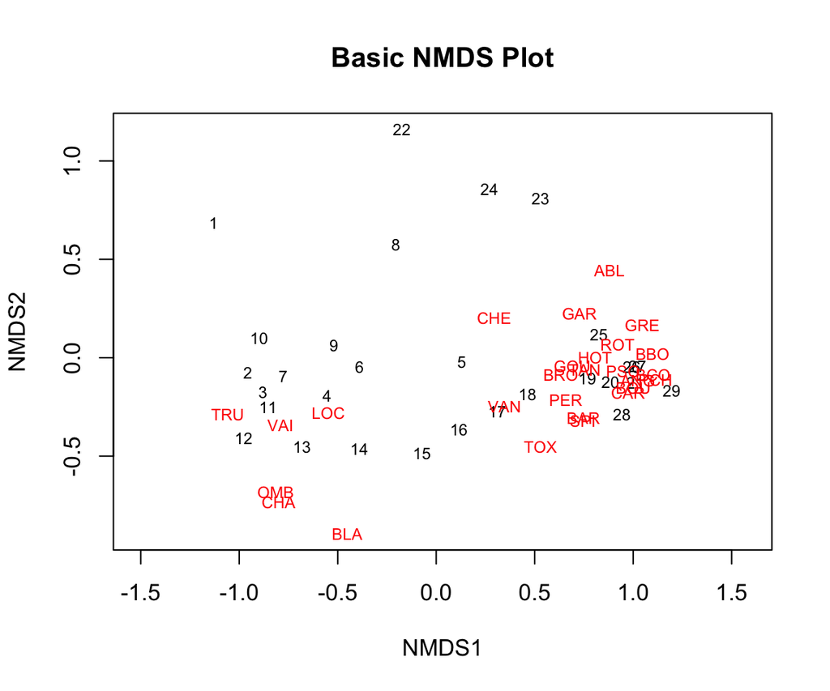

# Creating Enhanced NMDS Plots

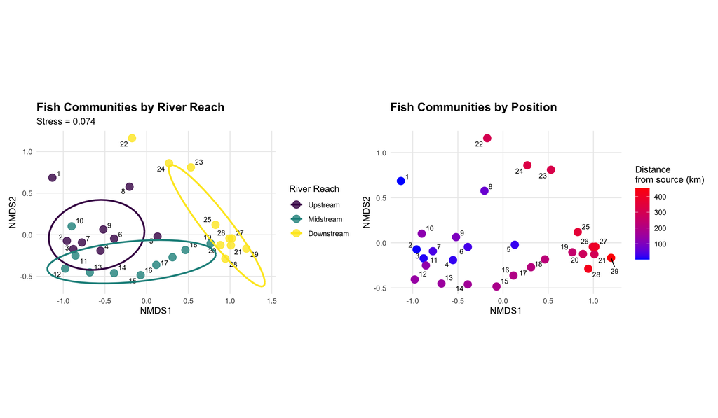

# Different plot using the actual hull definitions from vegan

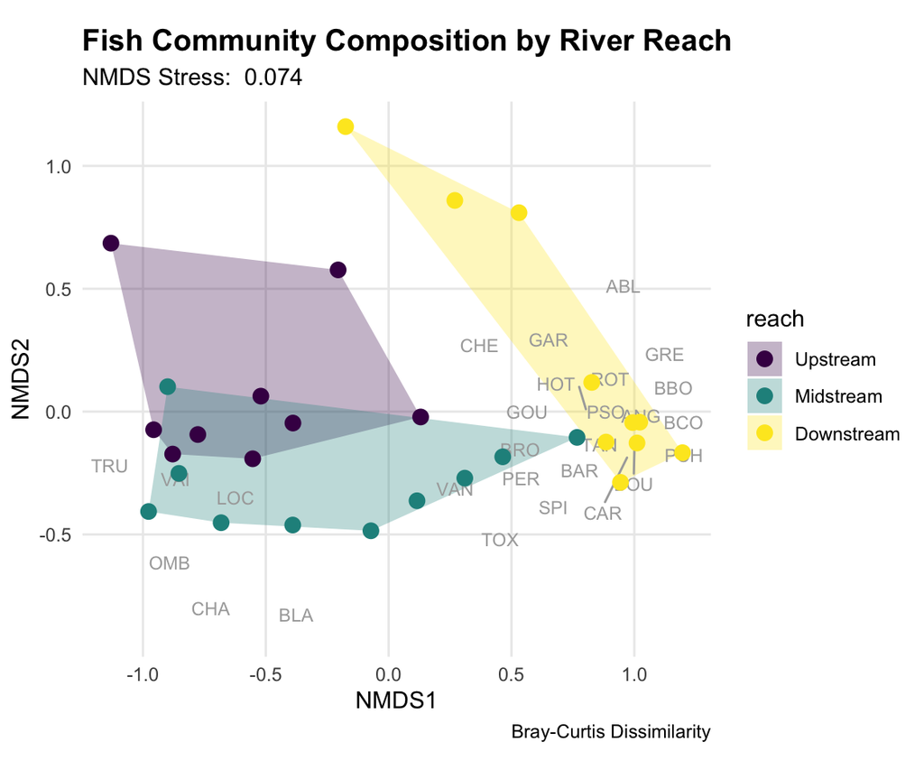

# PERMANOVA: Testing Multivariate Differences

- **What is PERMANOVA?**
  - **PERMANOVA (Permutational Multivariate ANOVA):**
    - **Purpose**: Test whether groups have different multivariate centroids
    - **Method**: ANOVA using distance matrices instead of raw data
    - **Advantage**: No distributional assumptions
    - **Permutation**: Creates null distribution by randomly reassigning group labels
  - **Think of it as:**
    - Multivariate version of ANOVA
    - Uses distances between samples instead of means
    - Tests: “Are the centers of these groups different in multivariate space?” .

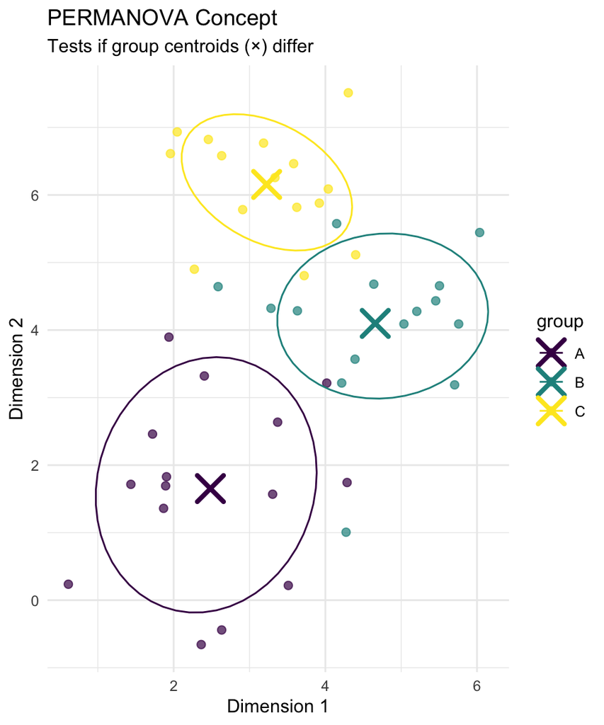

# How PERMANOVA Works

- **PERMANOVA Algorithm:**
  1. **Calculate distance matrix** between all pairs of samples
  2. **Calculate F-statistic** based on distances:
     - Between-group sum of squares
     - Within-group sum of squares
  3. **Permute group labels** randomly (e.g., 999 times)
  4. **Recalculate F-statistic** for each permutation
  5. **Compare observed F** to permutation distribution
  6. **P-value** = proportion of permuted F ≥ observed F
- **Why permutation?**
  - No assumptions about data distribution
  - Creates empirical null distribution
  - Accounts for complex dependency structures

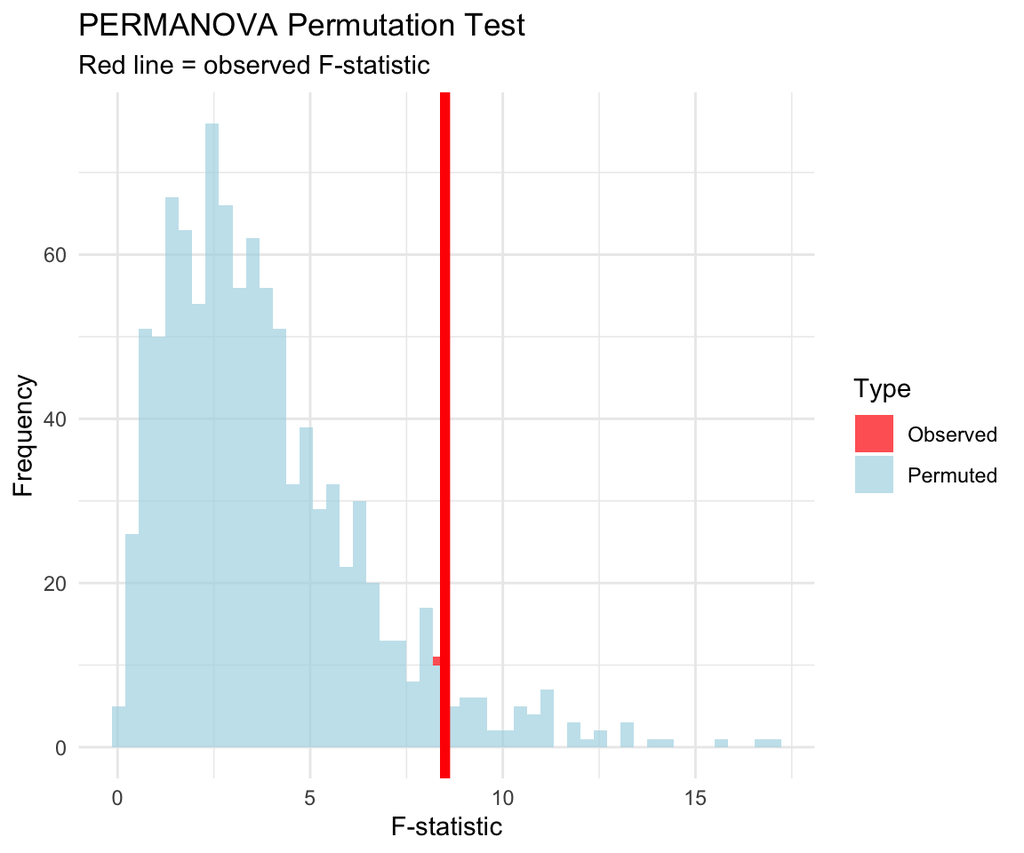

# PERMANOVA Hypotheses

- **Research Question:** *“Do fish communities differ significantly between river reaches?”*
- **Statistical Hypotheses:**
  - **H₀**: The centroids of fish communities are the same across all river reaches (Upper = Middle = Lower)
  - **H₁**: At least one river reach has a different community centroid
- **In practical terms:** -
  - H₀: River position doesn’t affect community composition
  - H₁: River position significantly affects community composition

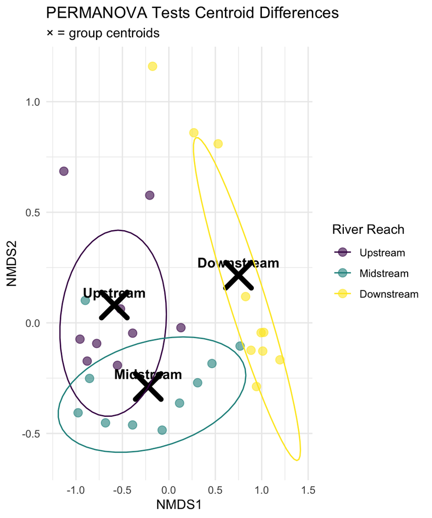

# PERMANOVA Assumptions

- **PERMANOVA Assumptions:**
- ✅ **Required:**
  1. **Independence**: Samples are independent
  2. **Exchangeability**: Under H₀, observations are exchangeable between groups
  3. **Homogeneity of dispersion**: Groups have similar multivariate spread
- ❌ **Not required:**
  - Normality or other distribution
  - Linearity
- **Checking Assumptions:**
  - **Use `betadisper()` to test homogeneity of dispersion**
  - If violated, PERMANOVA is testing dispersion differences and not location differences

```
## Homogeneity of dispersion test p-value: 0.8037
```

- vegan::betadisper() converts bray-curtis to euclidean distances to calculate distance from sample to center
- Principal Coordinates Analysis (PCoA) - ordination for distances between samples in a low-dimensional, Euclidean space

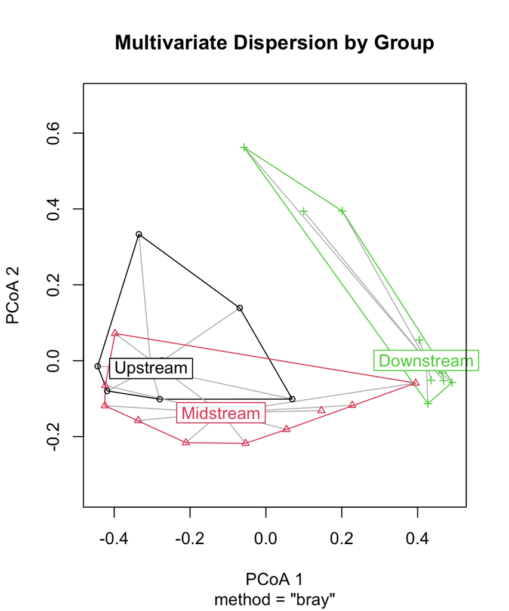

# Running PERMANOVA

- **PERMANOVA on Fish Communities**
  - **Line-by-line interpretation:**
    1. **reach**: The factor being tested (river reach)
    2. **Df = 2**: Degrees of freedom (3 groups - 1)
    3. **SumOfSqs**: Between-group sum of squares
    4. **R2**: Proportion of variance explained by reach
    5. **F**: F-statistic (ratio of between/within group variation)
    6. **Pr(>F)**: P-value from permutation test

```
## Permutation test for adonis under reduced model
## Permutation: free
## Number of permutations: 999
##
## adonis2(formula = spe_matrix ~ reach, data = doubs_env, permutations = 999, distance = "bray")
##          Df SumOfSqs      R2      F Pr(>F)
## Model     2   2.3631 0.42634 9.6614  0.001 ***
## Residual 26   3.1798 0.57366
## Total    28   5.5429 1.00000
## ---
## Signif. codes:  0 '***' 0.001 '**' 0.01 '*' 0.05 '.' 0.1 ' ' 1
```

# Pairwise PERMANOVA Tests

```
##                     pairs Df SumsOfSqs   F.Model        R2 p.value p.adjusted
## 1   Upstream vs Midstream  1 0.4068962  3.434528 0.1680747   0.021      0.063
## 2  Upstream vs Downstream  1 1.8495110 15.490360 0.4767679   0.001      0.003
## 3 Midstream vs Downstream  1 1.2829784  9.972485 0.3565105   0.001      0.003
##   sig
## 1
## 2   *
## 3   *
```

# Visualizing PERMANOVA Results

**Results:**

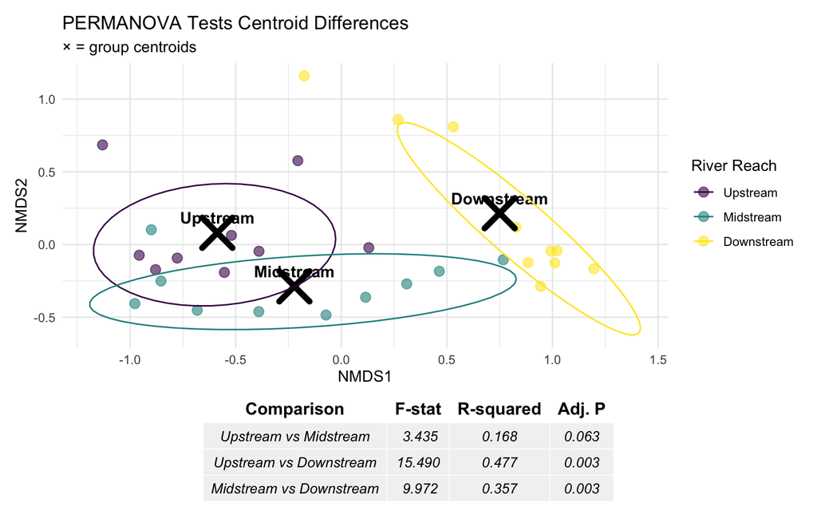

# ANOSIM: Analysis of Similarities

- **ANOSIM (Analysis of Similarities):**
  - **Purpose**: are samples w/in groups are more similar than samples between groups
  - **Method**: Based on rank dissimilarities
  - **Statistic**: R-statistic ranging from -1 to +1
  - **Interpretation**:
    - R ≈ 1: Groups are completely separated
    - R ≈ 0: Groups are indistinguishable
    - R < 0: More dissimilarity within groups than between
- **Differences from PERMANOVA:**
  - ANOSIM uses ranks of distances
  - PERMANOVA uses actual distances
  - ANOSIM is more robust but less powerful

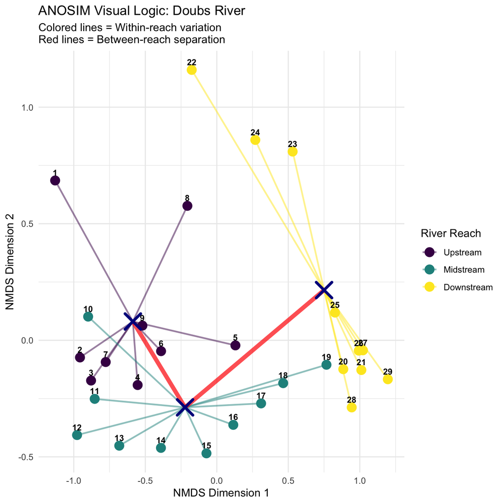

# How ANOSIM Works

- **ANOSIM Algorithm:**
  1. **Calculate dissimilarity matrix** between all samples
  2. **Rank all dissimilarities** from smallest to largest
  3. **Calculate mean rank** of within-group dissimilarities (r̄w)
  4. **Calculate mean rank** of between-group dissimilarities (r̄b)
  5. **Compute R-statistic**: R = (r̄b - r̄w) / (N(N-1)/4) where N = total number of samples
  6. **Permute group labels** and recalculate R many times
  7. **P-value** = proportion of permuted R ≥ observed R
- **R-statistic interpretation:**
  - R = 1: Perfect separation
  - R = 0: No separation
  - R = -1: More similar between groups than within

```r
# Run ANOSIM
anosim_result <- anosim(spe_matrix, doubs_env$reach,
                       distance = "bray", permutations = 999)

# Display results
anosim_result
##
## Call:
## anosim(x = spe_matrix, grouping = doubs_env$reach, permutations = 999,      distance = "bray")
## Dissimilarity: bray
##
## ANOSIM statistic R: 0.5082
##       Significance: 0.001
##
## Permutation: free
## Number of permutations: 999
```

# Running ANOSIM

- **ANOSIM Results Interpretation:**
  - **R = 0.5082** : This indicates “good” separation between groups
  - **p-value = 0.001 - significant result
  - **Biological meaning**: Fish communities well-separated between river reaches, with communities within each reach being much more similar to each other than to communities in other reaches
- “Within” box is clearly lower than the “Between” box
  - sites within same river reach tend to be more similar to each other (lower dissimilarity ranks) than sites in different reaches (higher dissimilarity ranks)
  - R statistic of 0.51 quantifies this separation
    - there’s clear differentiation, but with some overlap.
- Interpreting R:
  - R = 1 - Complete separation
    - all within-group dissimilarities smaller than between-group dissimilarities
  - R > 0.75 Well separated
  - R > 0.5 Separated, but overlapping
  - R > 0.25 Barely separated
  - R ≈ 0 No difference between groups

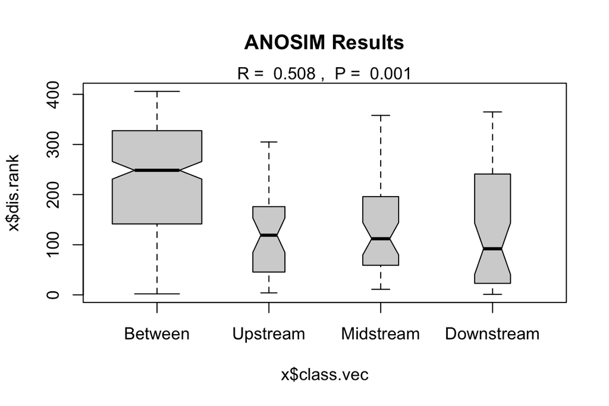

# ANOSIM vs PERMANOVA Comparison

```
## # A tibble: 2 × 6
##   Method    `Test Statistic` `P-value` Interpretation   `What it tests` Approach
##   <chr>     <chr>                <dbl> <chr>            <chr>           <chr>
## 1 PERMANOVA F = 9.66             0.001 Groups have dif… Differences in… Uses ac…
## 2 ANOSIM    R = 0.508            0.001 Excellent group… Overlap betwee… Uses ra…
```

# ANOSIM vs PERMANOVA Comparison

- **When to use which:**
  - **PERMANOVA:**
    - More powerful for detecting differences
    - Better for complex experimental designs
    - Can handle interactions and covariates
    - Preferred for most applications
  - **ANOSIM:**
    - More robust to outliers
    - Simpler interpretation
    - Good for initial exploratory analysis
    - Useful when distributions are very non-normal

# PERMANOVA vs ANOSIM

- **What’s the Difference? Three Scenarios**
- Both methods test whether groups differ, but they ask **different questions**:
  - **PERMANOVA asks:** *Do the group centroids differ in location?*
    - Uses actual squared distances and partitions variance like ANOVA
  - **ANOSIM asks:** *Are within-group dissimilarities smaller than between-group?*
    - Uses ranked distances to compares rank distributions

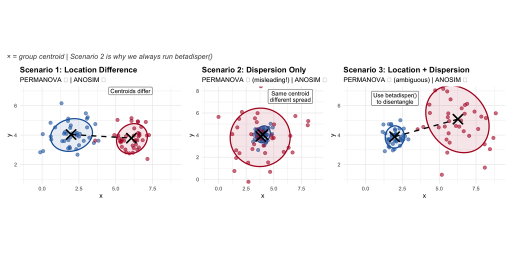

# Scenario 2 is Key!

- **The Problem:**
  - Groups A and B have the **same centroid** (same average community)
  - But Group B is much more **variable** (spread out)
  - PERMANOVA will detect this as “significant”!
- **Why?**
  - PERMANOVA tests distances from points to centroids
  - More spread = larger distances = detected as “different”

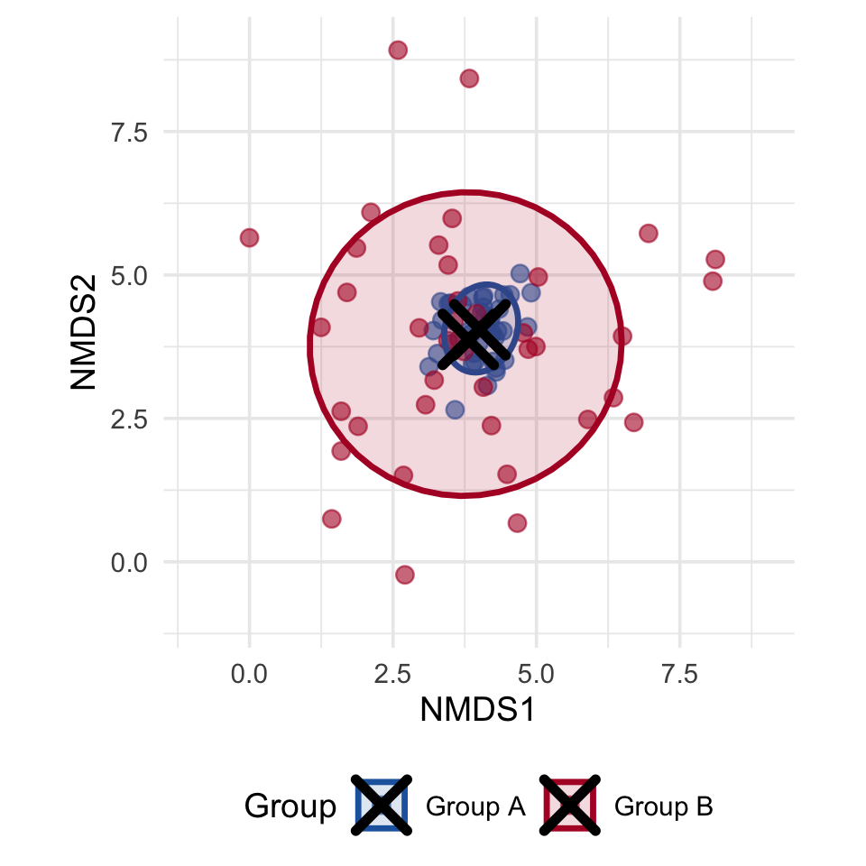

# Dispersion test for PERMANOVA

- **Solution:** Always run `betadisper()` before interpreting PERMANOVA!
  - What PERMANOVA “Sees”

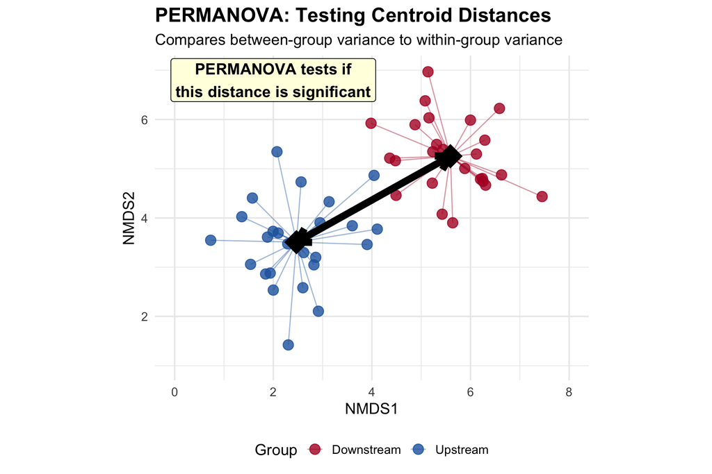

# What ANOSIM “Sees”

- This is different

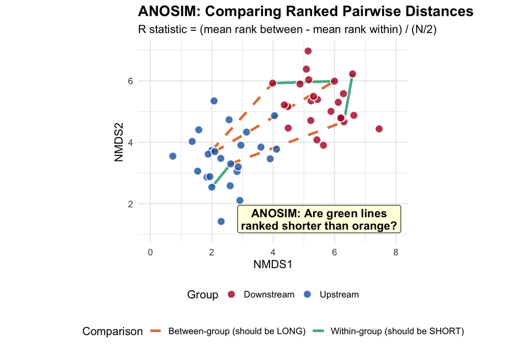